# MA611 Project

Haoze Tan

12/11/2021

```r
library(ggplot2)
library(ggfortify)
library(fpp2)
library(forecast)
library(tseries)
library(TSEntropies)
library(nonlinearTseries)
library(factoextra) #Extract and Visualize the Results of Multivariate Data Analyses///fviz_dend
library(TSclust)
```

```r
#input data
MOR30_mon <- read.csv("D:/OneDrive - Bentley University/Win-Desktop/MA611/611 data/MOR30_mon.csv")
REIT_mon <-read.csv("D:/OneDrive - Bentley University/Win-Desktop/MA611/611 data/REIT_mon.csv")
WGS10_mon <-read.csv("D:/OneDrive - Bentley University/Win-Desktop/MA611/611 data/WGS10_mon.csv")
labot <- read.csv("D:/OneDrive - Bentley University/Win-Desktop/MA611/Haoze/Labot Force Participation Rate (CIVPART)(1).csv")
```

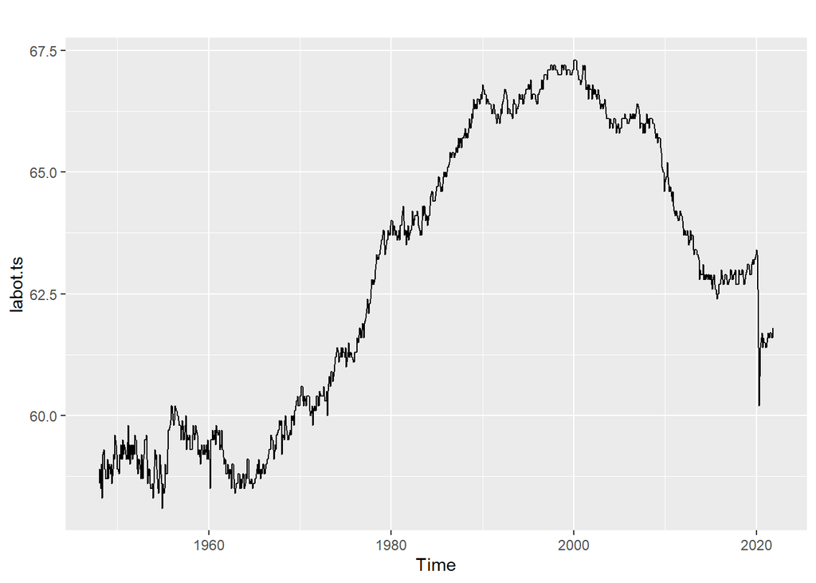

```r
##############################################################
#               Checking the labot ts plot and entropy--monthly data
##############################################################
CIVPACT <- labot$CIVPART
labot.ts <-ts(CIVPACT,end = c(2021,11),frequency = 12)
autoplot(labot.ts)
```

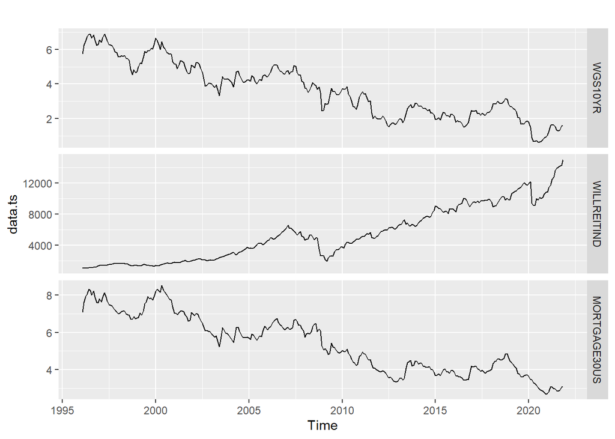

```r
##############################################################
#               Checking the ts plot and entropy--monthly data
##############################################################
MORTGAGE30US <- MOR30_mon$MORTGAGE30US
WILLREITIND <- REIT_mon$WILLREITIND
WGS10YR <- WGS10_mon$WGS10YR

data.ts <- ts(cbind(WGS10YR, WILLREITIND, MORTGAGE30US), end = c(2021,11),frequency = 12)
autoplot(data.ts, facets = T)
```

```r
matrix(c(SampEn(WGS10YR),SampEn(WILLREITIND),SampEn(MORTGAGE30US)),dimnames = list(c("WGS10YR","MORTGAGE30US","WGS10YR"), "Entr"))
```

[output not shown]

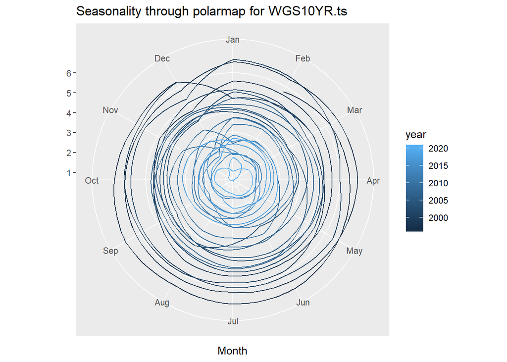

```r
##############################################################
#                         Polar Map--monthly data
##############################################################
WGS10YR.ts <- ts(WGS10YR, end = c(2021,11),frequency = 12)
WILLREITIND.ts <- ts(WILLREITIND, end = c(2021,11),frequency = 12)
MORTGAGE30US.ts <- ts(MORTGAGE30US, end = c(2021,11),frequency = 12)

ggseasonplot(WGS10YR.ts, year.labels = FALSE, continuous = TRUE, polar = TRUE)+
  ggtitle("Seasonality through polarmap for WGS10YR.ts")
```

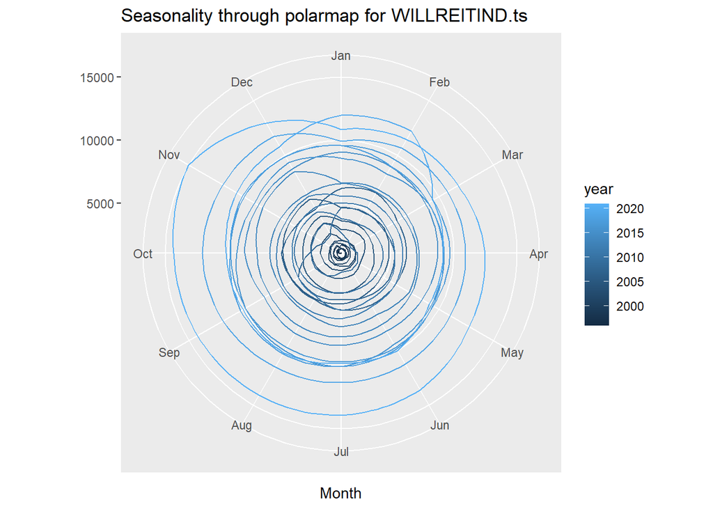

```r
ggseasonplot(WILLREITIND.ts, year.labels = FALSE, continuous = TRUE, polar = TRUE)+
  ggtitle("Seasonality through polarmap for WILLREITIND.ts")
```

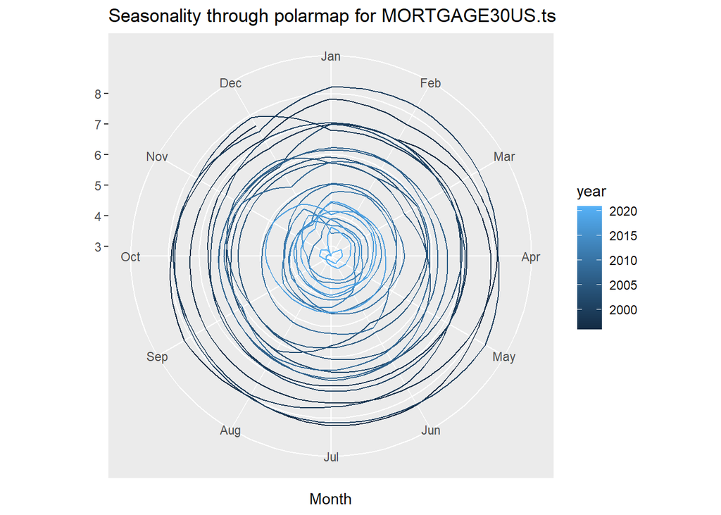

```r
ggseasonplot(MORTGAGE30US.ts, year.labels = FALSE, continuous = TRUE, polar = TRUE)+
  ggtitle("Seasonality through polarmap for MORTGAGE30US.ts")
```

```r
data2=ts(cbind(WGS10YR,WILLREITIND,MORTGAGE30US),end = c(2021,11),frequency = 12)
dissimilarity2=diss(data2,METHOD="COR")
dissimilarity2
```

```
##               WGS10YR WILLREITIND
## WILLREITIND  1.910725
## MORTGAGE30US 0.178513    1.922484
```

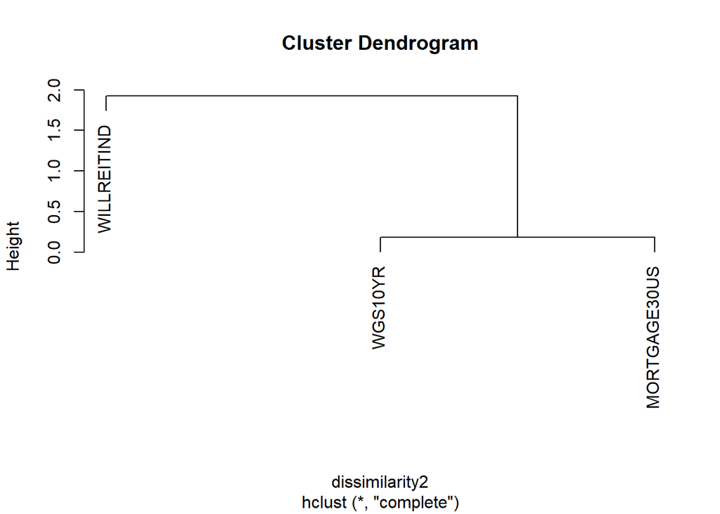

```r
hc.dpred2 <- hclust(dissimilarity2)
plot(hc.dpred2)
```

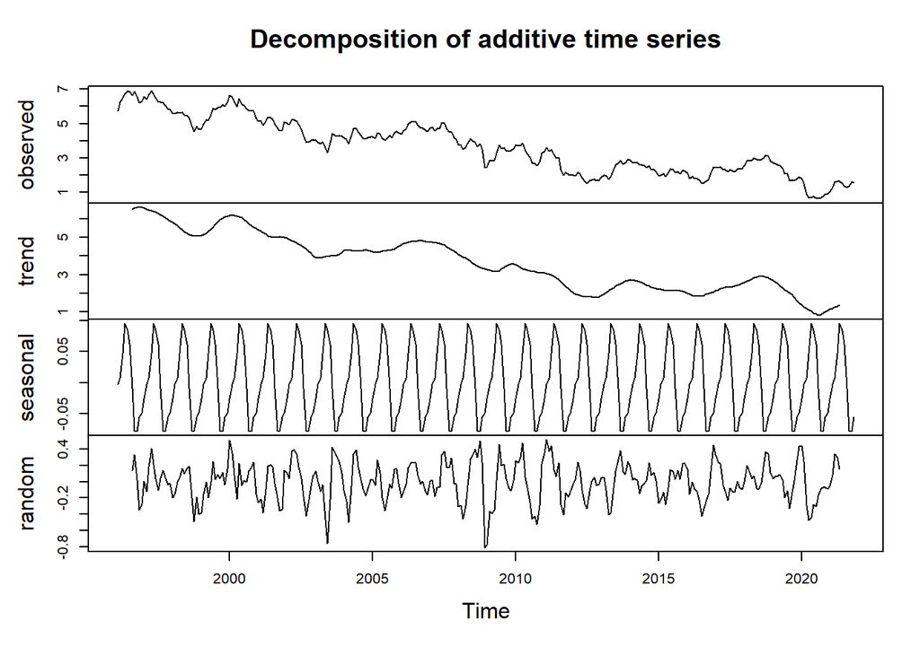

```r
##############################################################
#                   Moving Averages--monthly data
##############################################################
dec.WGS10YR=decompose(WGS10YR.ts)
dec.WILLREITIND=decompose(WILLREITIND.ts)
dec.MORTGAGE30US=decompose(MORTGAGE30US.ts)
plot(dec.WGS10YR)
```

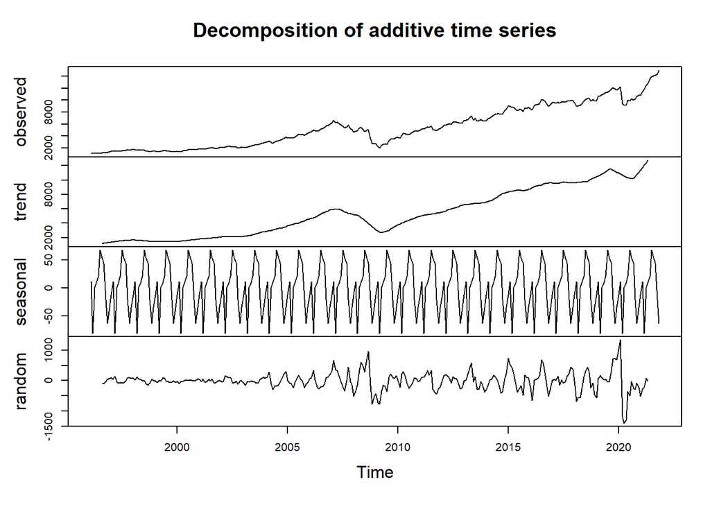

```r
plot(dec.WILLREITIND)
```

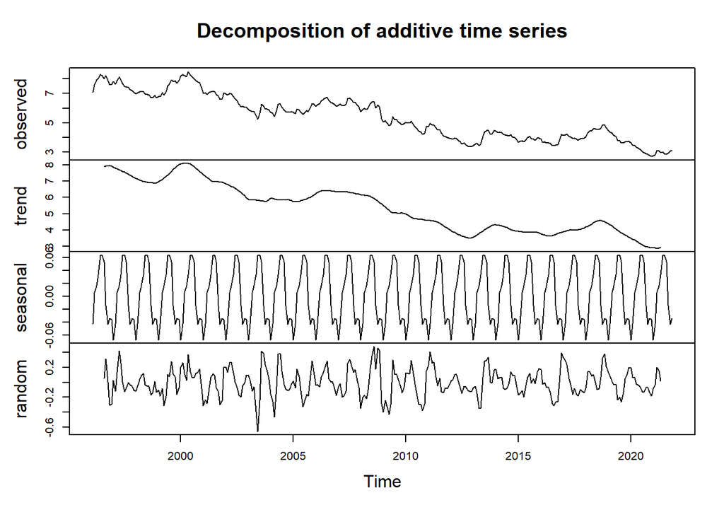

```r
plot(dec.MORTGAGE30US)
```

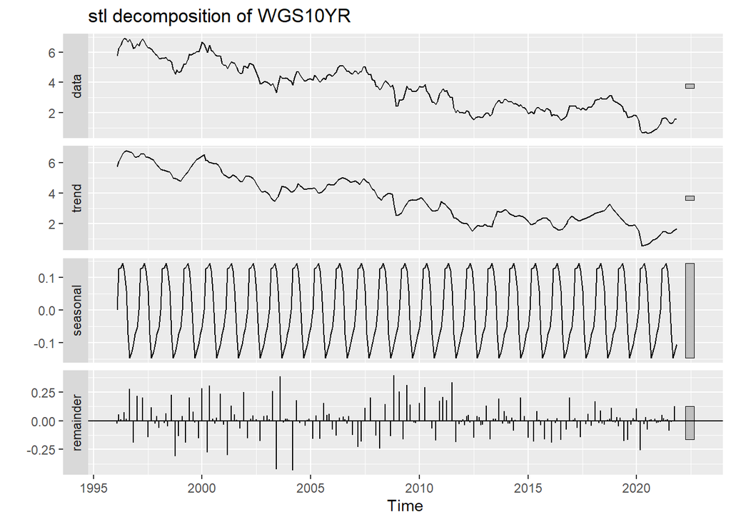

```r
##############################################################
#                   Stl--monthly data
##############################################################
decomp.WGS10YR = stl(WGS10YR.ts,t.window = 5,s.window="periodic", robust=TRUE)
autoplot(decomp.WGS10YR)+
  ggtitle("stl decomposition of WGS10YR")
```

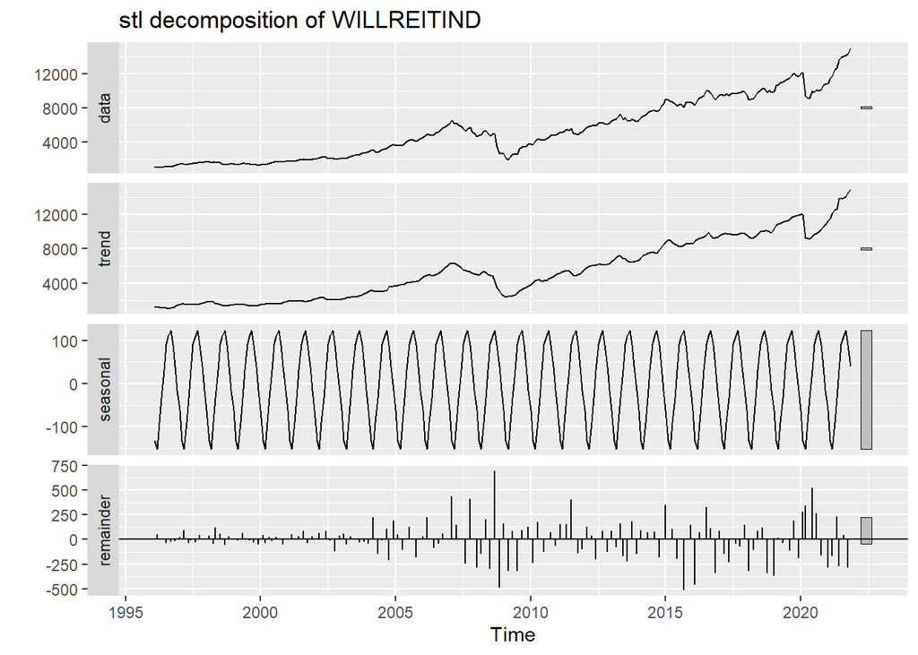

```r
decomp.WILLREITIND = stl(WILLREITIND.ts,t.window = 5,s.window="periodic", robust=TRUE)
autoplot(decomp.WILLREITIND)+
  ggtitle("stl decomposition of WILLREITIND")
```

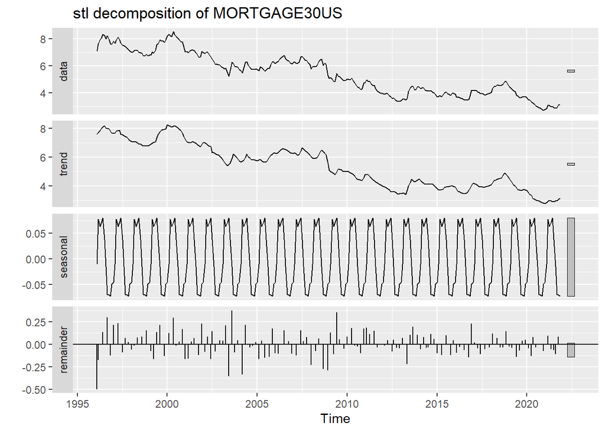

```r
decomp.MORTGAGE30US = stl(MORTGAGE30US.ts,t.window = 5,s.window="periodic", robust=TRUE)
autoplot(decomp.MORTGAGE30US)+
  ggtitle("stl decomposition of MORTGAGE30US")
```

```r
##############################################################
#                   FS & FT--monthly data
##############################################################
#--Checking the strength of trend and seasonality for "WGS10YR"---#
1-var(dec.WGS10YR$random,na.rm=TRUE)/var((dec.WGS10YR$trend+dec.WGS10YR$random),na.rm=TRUE)
```

```
## [1] 0.9762763
```

```r
1-var(dec.WGS10YR$random,na.rm=TRUE)/var((dec.WGS10YR$seasonal+dec.WGS10YR$random),na.rm=TRUE)
```

```
## [1] 0.05636835
```

```r
#--Checking the strength of trend and seasonality for "WILLREITIND"---#
1-var(dec.WILLREITIND$random,na.rm=TRUE)/var((dec.WILLREITIND$trend+dec.WILLREITIND$random),na.rm=TRUE)
```

```
## [1] 0.9913967
```

```r
1-var(dec.WILLREITIND$random,na.rm=TRUE)/var((dec.WILLREITIND$seasonal+dec.WILLREITIND$random),na.rm=TRUE)
```

```
## [1] 0.0200353
```

```r
#--Checking the strength of trend and seasonality for "MORTGAGE30US"---#
1-var(dec.MORTGAGE30US$random,na.rm=TRUE)/var((dec.MORTGAGE30US$trend+dec.MORTGAGE30US$random),na.rm=TRUE)
```

```
## [1] 0.9841644
```

```r
1-var(dec.MORTGAGE30US$random,na.rm=TRUE)/var((dec.MORTGAGE30US$seasonal+dec.MORTGAGE30US$random),na.rm=TRUE)
```

```
## [1] 0.05200056
```

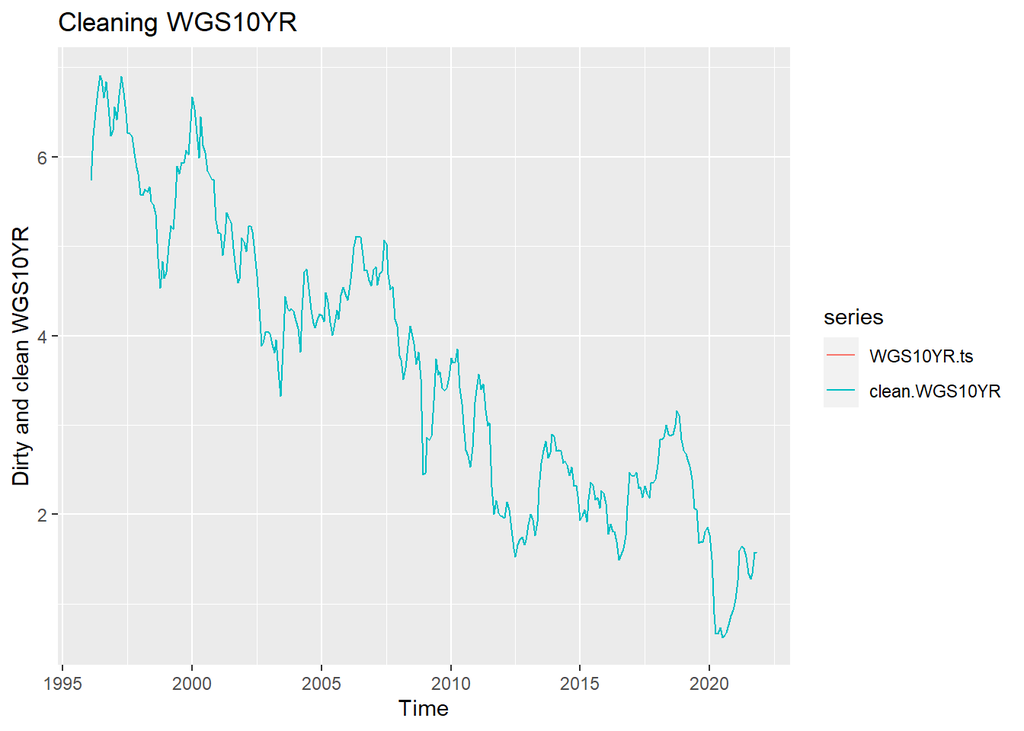

```r
##############################################################
#                    Clean--monthly data
##############################################################

#---Cleaning WGS10YR---#
clean.WGS10YR=tsclean(WGS10YR.ts, replace.missing = TRUE,lambda="auto")
#clean.WGS10YR
autoplot(ts(cbind(WGS10YR.ts,clean.WGS10YR),end = c(2021,11),frequency = 12))+
  ylab("Dirty and clean WGS10YR")+ggtitle("Cleaning WGS10YR")
```

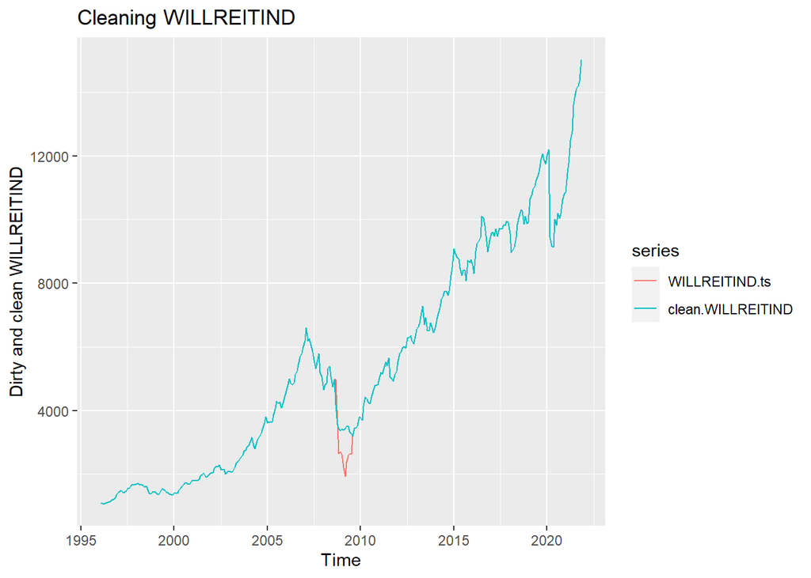

```r
#---Cleaning WILLREITIND---#
clean.WILLREITIND=tsclean(WILLREITIND.ts, replace.missing = TRUE,lambda="auto")
#clean.WILLREITIND
autoplot(ts(cbind(WILLREITIND.ts,clean.WILLREITIND),end = c(2021,11),frequency = 12))+
  ylab("Dirty and clean WILLREITIND")+ggtitle("Cleaning WILLREITIND")
```

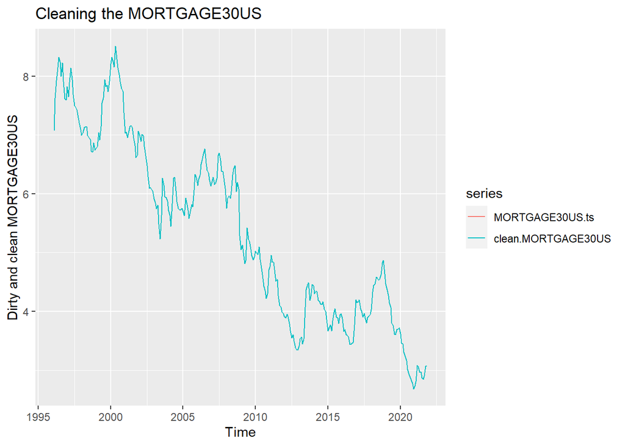

```r
#---Cleaning the MORTGAGE30US---#
clean.MORTGAGE30US=tsclean(MORTGAGE30US.ts, replace.missing = TRUE,lambda="auto")
#clean.MORTGAGE30US
autoplot(ts(cbind(MORTGAGE30US.ts,clean.MORTGAGE30US),end = c(2021,11),frequency = 12))+
  ylab("Dirty and clean MORTGAGE30US")+ggtitle("Cleaning the MORTGAGE30US")
```

#Set MOR30,REIT,WGS10(MONTHLY) TO ts–monthly data

```r
##############################################################
#                   ETS - monthly data
##############################################################

MOR30.mon.ts=ts(MOR30_mon$MORTGAGE30US,end = c(2021,11), frequency = 12)
REIT.mon.ts=ts(REIT_mon$WILLREITIND,end = c(2021,11), frequency = 12)
WGS10.mon.ts=ts(WGS10_mon$WGS10YR,end = c(2021,11), frequency = 12)
```

#Set up the train datasets–monthly data

```r
train.MOR30.mon=window(MOR30.mon.ts,end=end(MOR30.mon.ts)-c(5,0))
train.REIT.mon=window(REIT.mon.ts,end=end(REIT.mon.ts)-c(5,0))
train.WGS10.mon=window(WGS10.mon.ts,end=end(WGS10.mon.ts)-c(5,0))
```

#Run out the ets–monthly data

```r
ets(train.MOR30.mon)
```

```
## ETS(A,Ad,N)
##
## Call:
##  ets(y = train.MOR30.mon)
##
##   Smoothing parameters:
##     alpha = 0.9997
##     beta  = 0.1137
##     phi   = 0.8
##
##   Initial states:
##     l = 6.6288
##     b = 0.681
##
##   sigma:  0.1799
##
##      AIC     AICc      BIC
## 529.7718 530.1175 550.9006
```

```r
ets(train.REIT.mon)
```

```
## ETS(M,A,N)
##
## Call:
##  ets(y = train.REIT.mon)
##
##   Smoothing parameters:
##     alpha = 0.9999
##     beta  = 1e-04
##
##   Initial states:
##     l = 1019.6904
##     b = 22.379
##
##   sigma:  0.0506
##
##      AIC     AICc      BIC
## 3962.311 3962.557 3979.918
```

```r
ets(train.WGS10.mon)
```

```
## ETS(A,N,N)
##
## Call:
##  ets(y = train.WGS10.mon)
##
##   Smoothing parameters:
##     alpha = 0.9999
##
##   Initial states:
##     l = 5.7335
##
##   sigma:  0.2196
##
##      AIC     AICc      BIC
## 626.4682 626.5658 637.0326
```

#AUTOMIC—-monthly data

```r
auto.arima(train.REIT.mon,D=NA,max.q=0,max.P = 0,max.Q = 0,seasonal = F,stepwise = F,trace=T)
```

```
##
##  Fitting models using approximations to speed things up...
##
##  ARIMA(0,1,0)                               : 3389.625
##  ARIMA(0,1,0)            with drift         : 3386.525
##  ARIMA(1,1,0)                               : 3381.097
##  ARIMA(1,1,0)            with drift         : 3379.833
##  ARIMA(2,1,0)                               : 3383.791
##  ARIMA(2,1,0)            with drift         : 3382.137
##  ARIMA(3,1,0)                               : 3385.604
##  ARIMA(3,1,0)            with drift         : 3384.499
##  ARIMA(4,1,0)                               : 3384.552
##  ARIMA(4,1,0)            with drift         : 3384.314
##  ARIMA(5,1,0)                               : 3387.236
##  ARIMA(5,1,0)            with drift         : 3386.751
##
##  Now re-fitting the best model(s) without approximations...
##
##
##
##
##  Best model: ARIMA(1,1,0)            with drift
```

```
## Series: train.REIT.mon
## ARIMA(1,1,0) with drift
##
## Coefficients:
##          ar1    drift
##       0.1960  31.4486
## s.e.  0.0623  17.0108
##
## sigma^2 estimated as 47040:  log likelihood=-1691.8
## AIC=3389.59   AICc=3389.69   BIC=3400.15
```

#—-So let’s fit an ARIMA (1,1,0)—#–monthly data

```r
ari110=Arima(train.REIT.mon,c(1,1,0))
ari110
```

```
## Series: train.REIT.mon
## ARIMA(1,1,0)
##
## Coefficients:
##          ar1
##       0.2131
## s.e.  0.0621
##
## sigma^2 estimated as 47476:  log likelihood=-1693.45
## AIC=3390.9   AICc=3390.95   BIC=3397.94
```

```r
fitted(ari110)
```

[output not shown]

[output cut: 29 more lines]

```r
forecast(ari110)
```

```
##          Point Forecast    Lo 80     Hi 80    Lo 95     Hi 95
## Dec 2016       8918.440 8639.202  9197.678 8491.382  9345.498
## Jan 2017       8903.209 8464.205  9342.214 8231.810  9574.609
## Feb 2017       8899.963 8337.621  9462.306 8039.934  9759.992
## Mar 2017       8899.272 8234.711  9563.832 7882.914  9915.630
## Apr 2017       8899.124 8145.824  9652.424 7747.051 10051.197
## May 2017       8899.093 8066.405  9731.780 7625.607 10172.578
## Jun 2017       8899.086 7993.937  9804.235 7514.781 10283.391
## Jul 2017       8899.085 7926.859  9871.311 7412.193 10385.976
## Aug 2017       8899.084 7864.119  9934.050 7316.241 10481.928
## Sep 2017       8899.084 7804.971  9993.198 7225.782 10572.387
## Oct 2017       8899.084 7748.860 10049.308 7139.968 10658.200
## Nov 2017       8899.084 7695.362 10102.806 7058.151 10740.018
## Dec 2017       8899.084 7644.143 10154.025 6979.818 10818.351
## Jan 2018       8899.084 7594.934 10203.234 6904.559 10893.610
## Feb 2018       8899.084 7547.515 10250.653 6832.038 10966.131
## Mar 2018       8899.084 7501.705 10296.464 6761.977 11036.192
## Apr 2018       8899.084 7457.349 10340.819 6694.141 11104.028
## May 2018       8899.084 7414.318 10383.850 6628.330 11169.838
## Jun 2018       8899.084 7372.499 10425.669 6564.374 11233.794
## Jul 2018       8899.084 7331.796 10466.372 6502.124 11296.045
## Aug 2018       8899.084 7292.123 10506.045 6441.450 11356.719
## Sep 2018       8899.084 7253.407 10544.762 6382.238 11415.930
## Oct 2018       8899.084 7215.581 10582.588 6324.388 11473.781
## Nov 2018       8899.084 7178.586 10619.583 6267.809 11530.360
```

#forecast–monthly data

```r
forecast(ets(train.REIT.mon))
```

```
##          Point Forecast    Lo 80     Hi 80    Lo 95     Hi 95
## Dec 2016       9012.557 8428.203  9596.910 8118.865  9906.248
## Jan 2017       9035.172 8207.206  9863.138 7768.907 10301.437
## Feb 2017       9057.788 8041.788 10073.788 7503.950 10611.626
## Mar 2017       9080.404 7904.961 10255.847 7282.720 10878.088
## Apr 2017       9103.020 7786.294 10419.746 7089.261 11116.778
## May 2017       9125.636 7680.446 10570.825 6915.409 11335.863
## Jun 2017       9148.251 7584.252 10712.251 6756.320 11540.183
## Jul 2017       9170.867 7495.652 10846.083 6608.847 11732.888
## Aug 2017       9193.483 7413.220 10973.746 6470.806 11916.160
## Sep 2017       9216.099 7335.919 11096.279 6340.611 12091.587
## Oct 2017       9238.715 7262.966 11214.464 6217.068 12260.362
## Nov 2017       9261.331 7193.756 11328.905 6099.248 12423.413
## Dec 2017       9283.946 7127.808 11440.085 5986.417 12581.476
## Jan 2018       9306.562 7064.733 11548.392 5877.980 12735.145
## Feb 2018       9329.178 7004.209 11654.147 5773.445 12884.911
## Mar 2018       9351.794 6945.971 11757.616 5672.406 13031.182
## Apr 2018       9374.410 6889.793 11859.026 5574.516 13174.303
## May 2018       9397.026 6835.482 11958.569 5479.483 13314.568
## Jun 2018       9419.641 6782.872 12056.411 5387.051 13452.232
## Jul 2018       9442.257 6731.820 12152.694 5297.002 13587.513
## Aug 2018       9464.873 6682.200 12247.546 5209.142 13720.605
## Sep 2018       9487.489 6633.900 12341.078 5123.302 13851.676
## Oct 2018       9510.105 6586.823 12433.386 5039.331 13980.878
## Nov 2018       9532.721 6540.881 12524.560 4957.097 14108.344
```

#—Graphic comparison—-#–monthly data

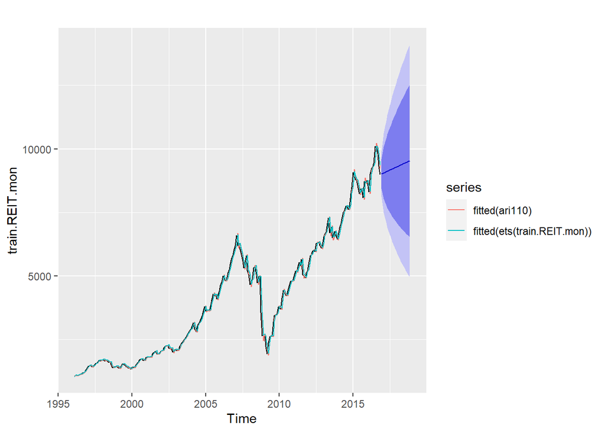

```r
autoplot(train.REIT.mon)+autolayer(fitted(ari110))+autolayer(fitted(ets(train.REIT.mon)))+
  autolayer(forecast(ari110))+autolayer(forecast(ets(train.REIT.mon)))
```

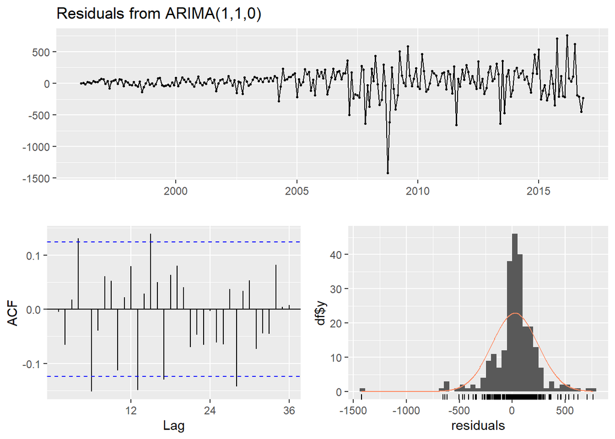

```
##
##  Ljung-Box test
##
## data:  Residuals from ARIMA(1,1,0)
## Q* = 41.794, df = 23, p-value = 0.009592
##
## Model df: 1.   Total lags used: 24
```

```r
##############################################################
#                   Residual diagnostics - monthly data
##############################################################
checkresiduals(ari110)
```

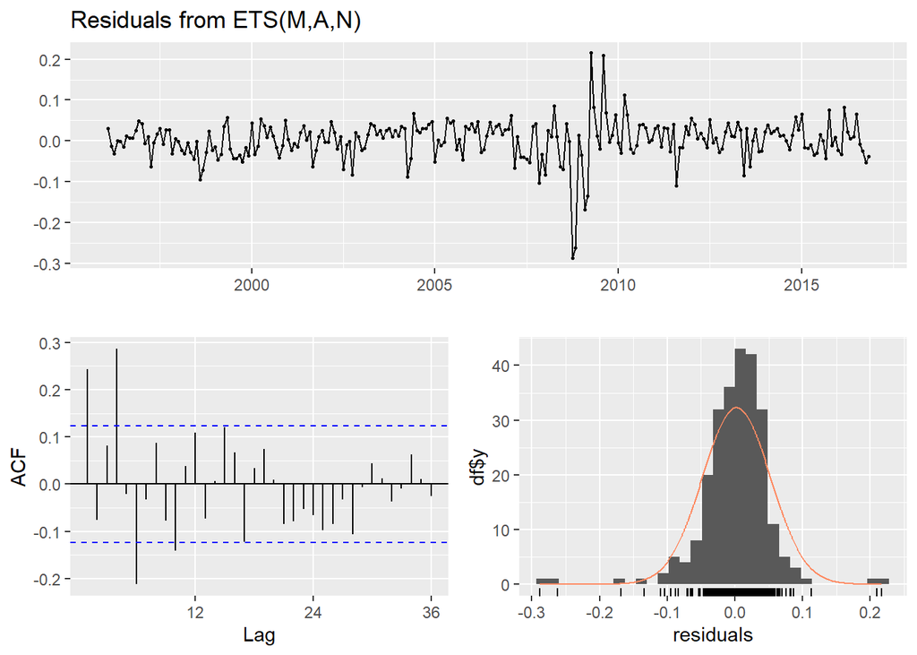

```
##
##  Ljung-Box test
##
## data:  Residuals from ETS(M,A,N)
## Q* = 81.356, df = 20, p-value = 2.308e-09
##
## Model df: 4.   Total lags used: 24
```

```r
checkresiduals(ets(train.REIT.mon))
```

```r
##############################################################
#                   Accuracy checking - monthly data
##############################################################

accuracy(forecast(ari110),REIT.mon.ts)
```

```
##                     ME     RMSE      MAE       MPE     MAPE     MASE
## Training set  24.63294 217.0172 140.9534 0.5729187 3.455990 0.184244
## Test set     787.25688 857.9617 787.2569 8.0115889 8.011589 1.029045
##                      ACF1 Theil's U
## Training set -0.004642325        NA
## Test set      0.697616378  3.502006
```

```r
accuracy(forecast(ets(train.REIT.mon)),REIT.mon.ts)
```

```
##                      ME     RMSE      MAE         MPE     MAPE      MASE
## Training set   9.472767 220.0569 142.3575 -0.07339119 3.528125 0.1860794
## Test set     414.727525 521.4969 488.8528  4.18181387 5.001633 0.6389929
##                   ACF1 Theil's U
## Training set 0.1946728        NA
## Test set     0.7113850  2.133478
```

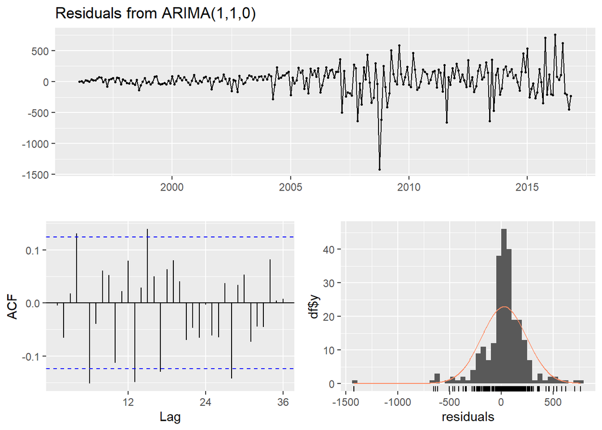

```
##
##  Ljung-Box test
##
## data:  Residuals from ARIMA(1,1,0)
## Q* = 41.794, df = 23, p-value = 0.009592
##
## Model df: 1.   Total lags used: 24
```

```r
##############################################################
#                   residuals checking - monthly data
##############################################################

checkresiduals(ari110)
```

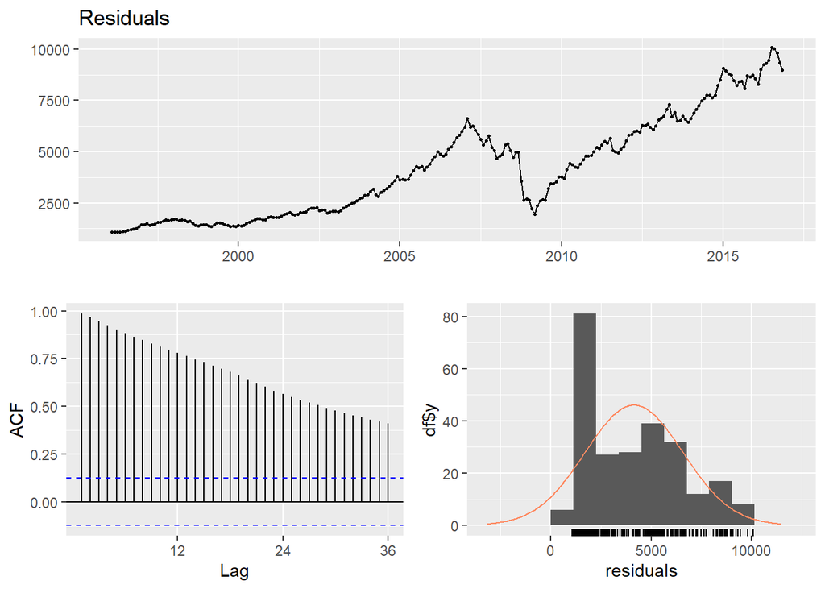

```r
checkresiduals(train.REIT.mon)
```

#Bootstrapping 在统计学中是一个非常有用的工具，它在R #中很容易实现。当人们怀疑通常的分布假设和渐近结果是否有效和准确时，Bootstrapping 会派上用场。Bootstrapping #是一种非参数方法，可让我们计算估计的标准误差、置信区间和假设检验。

#通常引导遵循相同的基本步骤： #对给定数据集重新采样指定次数 #计算每个样本的特定统计量 #找出该统计量分布的标准差

```r
##############################################################
#                   Bagged forecasting - monthly data
##############################################################
t0 <- Sys.time()
#bld.mbb.bootstrap ---Generates bootstrapped versions of a time series using the Box-Cox and Loess-based decomposition bootstrap.
bm=baggedModel(train.REIT.mon, bootstrapped_series = bld.mbb.bootstrap(train.REIT.mon, 50,block_size = NULL))
accuracy(forecast(bm),REIT.mon.ts)
```

```
##                      ME     RMSE      MAE        MPE     MAPE      MASE
## Training set   19.92951 237.1706 167.0195 -0.2527017 4.187638 0.2183158
## Test set     -246.62563 404.4811 267.7615 -2.6492375 2.856743 0.3499984
##                   ACF1 Theil's U
## Training set 0.6119762        NA
## Test set     0.7238800  1.741412
```

```
## For a multivariate time series, specify a seriesname for each time series. Defaulting to column names.
```

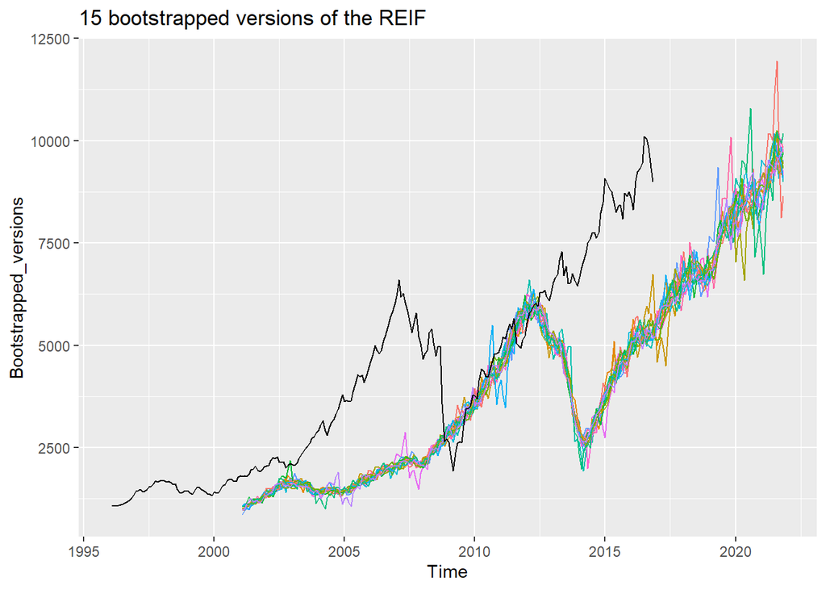

```r
bootstrapped_versions=bld.mbb.bootstrap(train.REIT.mon,15)
boot.ts=ts(as.data.frame(bootstrapped_versions),end = c(2021,11),frequency = 12)
autoplot(train.REIT.mon) +
  autolayer(boot.ts, colour=TRUE) +
  autolayer(train.REIT.mon, colour=FALSE)+  ylab("Bootstrapped_versions")+guides(colour="none")+
  ggtitle("15 bootstrapped versions of the REIF")
```

```r
bm=baggedModel(train.REIT.mon, bootstrapped_series = bld.mbb.bootstrap(train.REIT.mon, 15))
accuracy(forecast(bm),REIT.mon.ts)
```

```
##                      ME     RMSE      MAE       MPE     MAPE      MASE
## Training set   20.70179 229.6596 160.3110 -0.196039 4.138494 0.2095469
## Test set     -428.73747 539.4760 428.7375 -4.532377 4.532377 0.5604144
##                   ACF1 Theil's U
## Training set 0.5890661        NA
## Test set     0.7284621  2.297525
```

```r
forecast(bm)
```

```
##          Point Forecast   Lo 100   Hi 100
## Dec 2016       9751.088 9012.557 10253.59
## Jan 2017       9794.083 9035.172 10366.86
## Feb 2017       9817.976 9057.788 10413.31
## Mar 2017       9858.754 9080.404 10635.95
## Apr 2017       9930.018 9103.020 11002.25
## May 2017       9991.934 9125.636 11181.84
## Jun 2017       9984.602 9148.251 11041.31
## Jul 2017      10018.462 9170.867 11150.45
## Aug 2017      10039.314 9193.483 11161.79
## Sep 2017      10060.750 9216.099 11218.18
## Oct 2017      10055.464 9238.715 10988.41
## Nov 2017      10054.859 9261.331 10858.27
## Dec 2017      10118.940 9283.946 11169.79
## Jan 2018      10155.297 9306.562 11313.29
## Feb 2018      10172.124 9329.178 11331.88
## Mar 2018      10207.524 9351.794 11542.74
## Apr 2018      10275.711 9374.410 11909.11
## May 2018      10334.357 9397.026 12073.13
## Jun 2018      10320.475 9419.641 11892.61
## Jul 2018      10350.475 9442.257 11982.25
## Aug 2018      10366.909 9464.873 11967.60
## Sep 2018      10384.392 9487.489 12002.13
## Oct 2018      10373.909 9510.105 11731.88
## Nov 2018      10369.068 9532.721 11569.71
```

```r
forecast(Arima(train.REIT.mon,c(1,1,0)),level = c(99.95))
```

```
##          Point Forecast Lo 99.95  Hi 99.95
## Dec 2016       8918.440 8160.016  9676.864
## Jan 2017       8903.209 7710.852 10095.567
## Feb 2017       8899.963 7372.613 10427.314
## Mar 2017       8899.272 7094.292 10704.251
## Apr 2017       8899.124 6853.124 10945.124
## May 2017       8899.093 6637.473 11160.712
## Jun 2017       8899.086 6440.658 11357.514
## Jul 2017       8899.085 6258.471 11539.698
## Aug 2017       8899.084 6088.067 11710.102
## Sep 2017       8899.084 5927.418 11870.750
## Oct 2017       8899.084 5775.020 12023.149
## Nov 2017       8899.084 5629.717 12168.451
## Dec 2017       8899.084 5490.603 12307.565
## Jan 2018       8899.084 5356.949 12441.220
## Feb 2018       8899.084 5228.157 12570.011
## Mar 2018       8899.084 5103.734 12694.435
## Apr 2018       8899.084 4983.262 12814.907
## May 2018       8899.084 4866.387 12931.782
## Jun 2018       8899.084 4752.805 13045.363
## Jul 2018       8899.084 4642.253 13155.915
## Aug 2018       8899.084 4534.501 13263.668
## Sep 2018       8899.084 4429.345 13368.824
## Oct 2018       8899.084 4326.606 13471.562
## Nov 2018       8899.084 4226.127 13572.042
```

```r
t1 <- Sys.time()
t <- t1-t0
```

#NEST is WEEKLY WEEKLY WEEKLY!!!!!!!!!!!!!!!!!!!!!!!!!!!!!! #NEST is WEEKLY WEEKLY WEEKLY!!!!!!!!!!!!!!!!!!!!!!!!!!!!!! #NEST is WEEKLY WEEKLY WEEKLY!!!!!!!!!!!!!!!!!!!!!!!!!!!!!! #NEST is WEEKLY WEEKLY WEEKLY!!!!!!!!!!!!!!!!!!!!!!!!!!!!!! #NEST is WEEKLY WEEKLY WEEKLY!!!!!!!!!!!!!!!!!!!!!!!!!!!!!! #NEST is WEEKLY WEEKLY WEEKLY!!!!!!!!!!!!!!!!!!!!!!!!!!!!!!

```r
#input data
MOR30_week <- read.csv("D:/OneDrive - Bentley University/Win-Desktop/MA611/611 data/MOR30_week.csv")
REIT_week <-read.csv("D:/OneDrive - Bentley University/Win-Desktop/MA611/611 data/REIT_week.csv")
WGS10_week <-read.csv("D:/OneDrive - Bentley University/Win-Desktop/MA611/611 data/WGS10_week.csv")
```

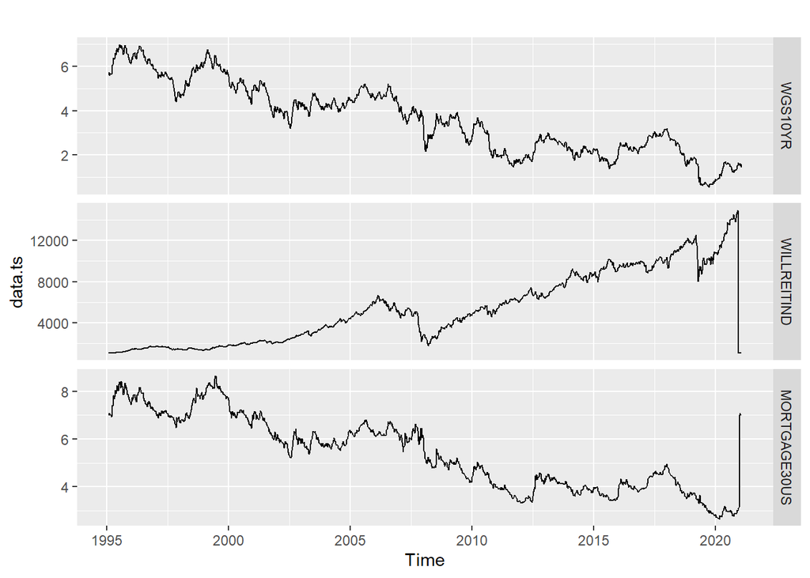

```r
##############################################################
#               Checking the ts plot and entropy--week data
##############################################################
MORTGAGE30US <- MOR30_week$MORTGAGE30US
WILLREITIND <- REIT_week$WILLREITIND
WGS10YR <- WGS10_week$WGS10YR

data.ts <- ts(cbind(WGS10YR, WILLREITIND, MORTGAGE30US), end = c(2021,5),frequency = 52)
autoplot(data.ts, facets = T)
```

```r
matrix(c(SampEn(WGS10YR),SampEn(WILLREITIND),SampEn(MORTGAGE30US)),dimnames = list(c("WGS10YR","MORTGAGE30US","WGS10YR"), "Entr"))
```

[output not shown]

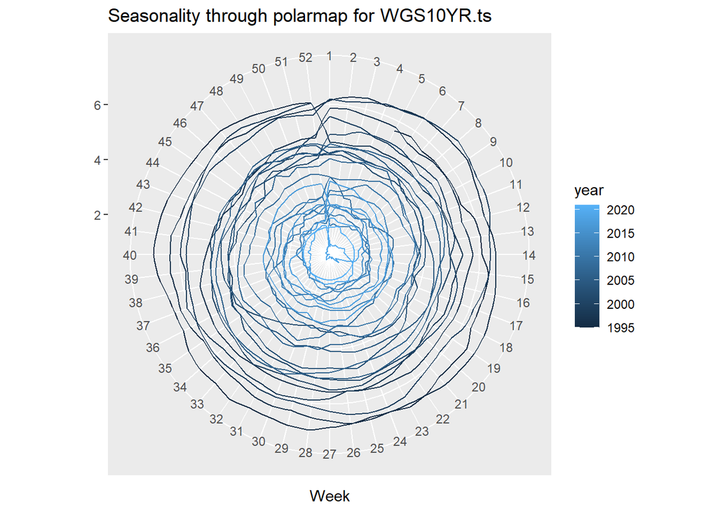

```r
##############################################################
#                         Polar Map--week data
##############################################################
WGS10YR.ts <- ts(WGS10YR, end = c(2021,5),frequency = 52)
WILLREITIND.ts <- ts(WILLREITIND, end = c(2021,5),frequency = 52)
MORTGAGE30US.ts <- ts(MORTGAGE30US, end = c(2021,5),frequency = 52)

ggseasonplot(WGS10YR.ts, year.labels = FALSE, continuous = TRUE, polar = TRUE)+
  ggtitle("Seasonality through polarmap for WGS10YR.ts")
```

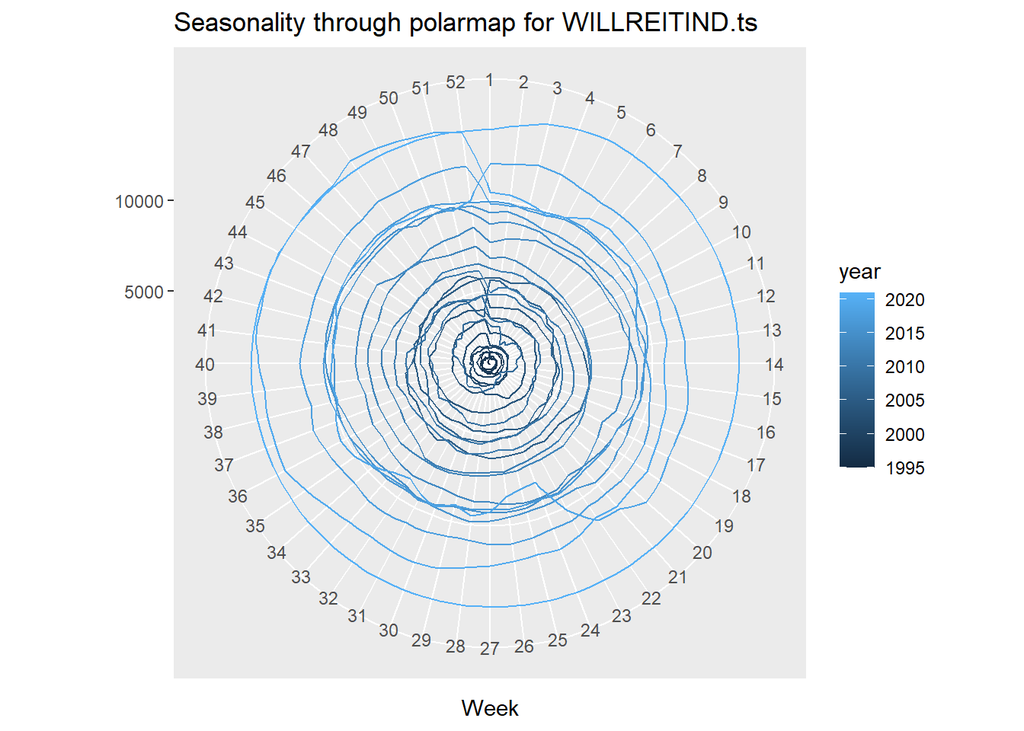

```r
ggseasonplot(WILLREITIND.ts, year.labels = FALSE, continuous = TRUE, polar = TRUE)+
  ggtitle("Seasonality through polarmap for WILLREITIND.ts")
```

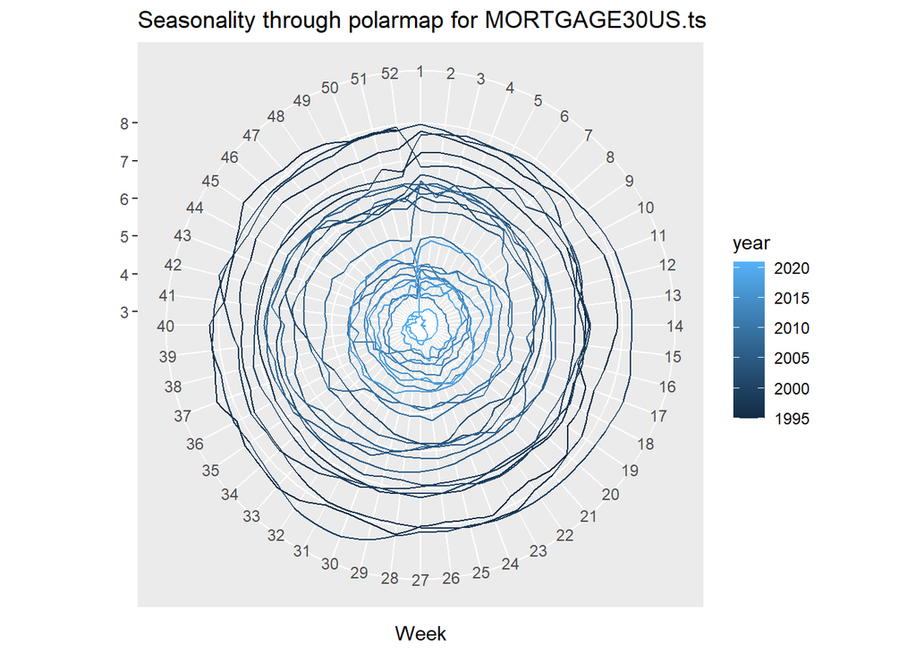

```r
ggseasonplot(MORTGAGE30US.ts, year.labels = FALSE, continuous = TRUE, polar = TRUE)+
  ggtitle("Seasonality through polarmap for MORTGAGE30US.ts")
```

```r
data2=ts(cbind(WGS10YR,WILLREITIND,MORTGAGE30US),end = c(2021,5),frequency = 52)
dissimilarity2=diss(data2,METHOD="COR")
dissimilarity2
```

```
##                WGS10YR WILLREITIND
## WILLREITIND  1.9016310
## MORTGAGE30US 0.2327092   1.9191768
```

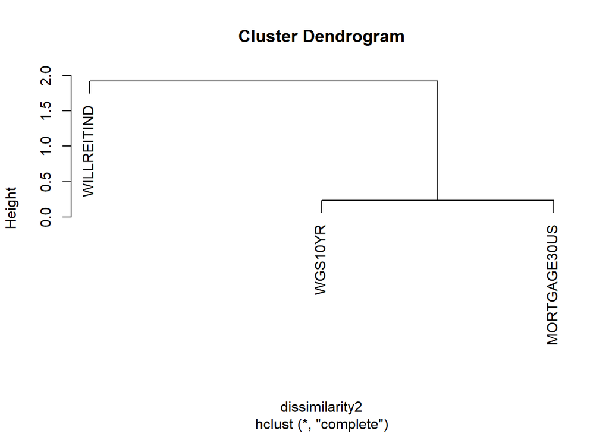

```r
hc.dpred2 <- hclust(dissimilarity2)
plot(hc.dpred2)
```

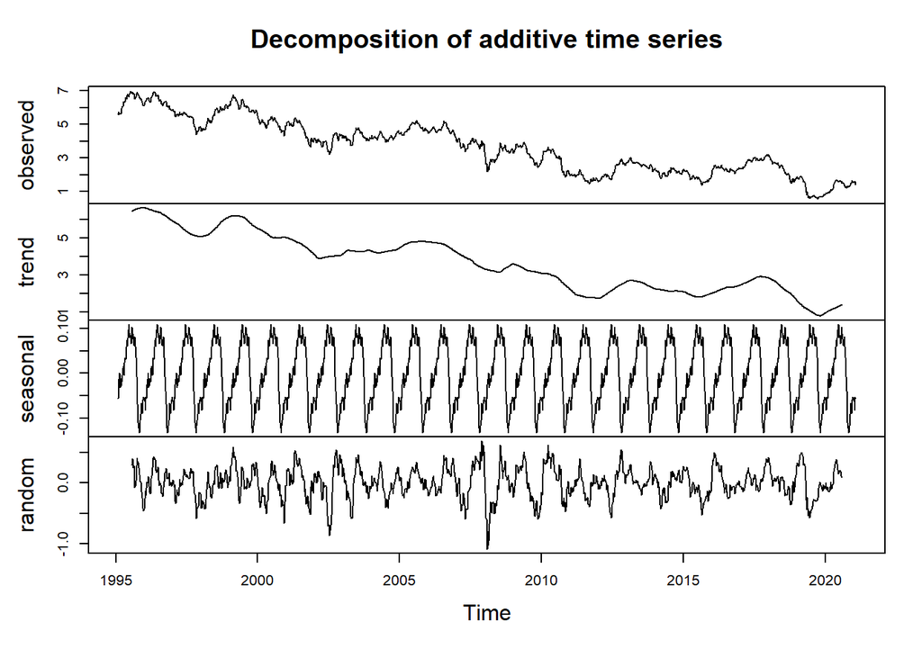

```r
##############################################################
#                   Moving Averages--week data
##############################################################
dec.WGS10YR=decompose(WGS10YR.ts)
dec.WILLREITIND=decompose(WILLREITIND.ts)
dec.MORTGAGE30US=decompose(MORTGAGE30US.ts)
plot(dec.WGS10YR)
```

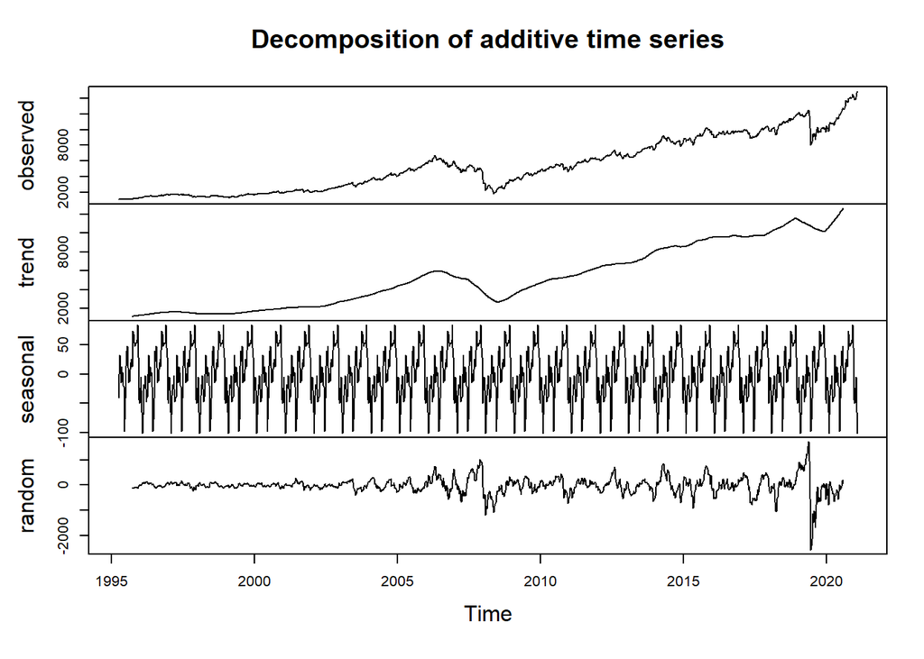

```r
plot(dec.WILLREITIND)
```

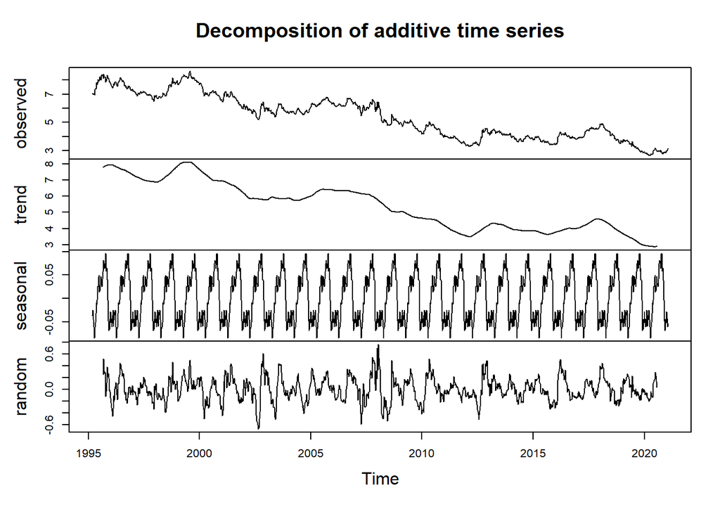

```r
plot(dec.MORTGAGE30US)
```

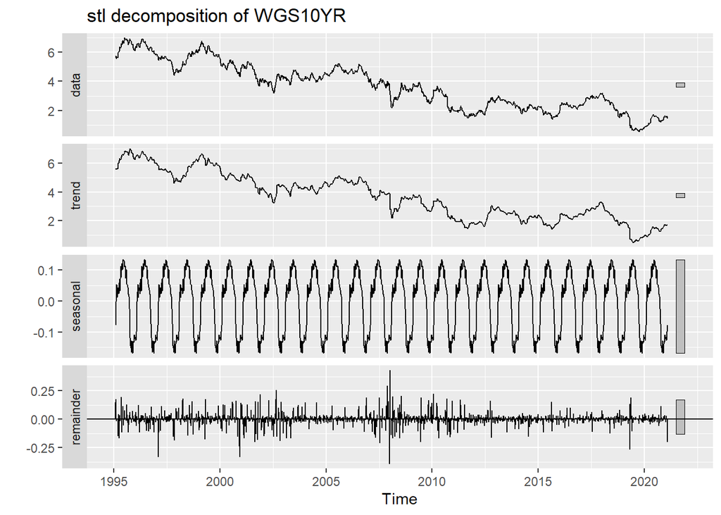

```r
##############################################################
#                   Stl--week data
##############################################################
decomp.WGS10YR = stl(WGS10YR.ts,t.window = 5,s.window="periodic", robust=TRUE)
autoplot(decomp.WGS10YR)+
  ggtitle("stl decomposition of WGS10YR")
```